# US Storm Data Analysis

Mukarram Mukhtar

03/16/2019

## 1. Synopsis

In this article we’ll make use of data from NOAA Storm Database. We’ll try to answer some basic questions about severe weather events. We’ll also show the code for the entire analysis. The analysis consists of tables, figures, and/or other summaries. We’ll also use R package(s) to support our analysis. The two basic questions that we’ll address in this analyis are:

1. Across the United States, which types of events are most harmful with respect to population health?
2. Across the United States, which types of events have the greatest economic consequences?

Before we begin the step-by-step process, we’ll load the necessary libraries for the rest of the steps in process:

```r
library(data.table)
library(ggplot2)
library(gridExtra)
library(ggpubr)
library(dplyr)
```

## 2. Data Processing

#### 2.1 Downloading the zip file

```r
if(!file.exists("./StormData.csv.bz2"))
{
    download.file("https://d396qusza40orc.cloudfront.net/repdata%2Fdata%2FStormData.csv.bz2", "./StormData.csv.bz2")
}
```

#### 2.2 Loading the data

Once the file is available, then we’ll read the file in data frame:

```r
if(file.exists("./StormData.csv.bz2"))
{
    dtStorm = read.table("StormData.csv.bz2", header = TRUE, sep = ",", quote = "\"")
}
```

#### 2.3 Calculating weather related injuries and fatalities.

##### 2.3.1 Data Transformations:

In order to calculate the number of injuries and fatalities, we must group the data table by EVTYPE and sum the injuries and fatalities respectively. Moreover, we need to sort the respective tables in descending order. Finally, we pick up the top 10 items.

```r
storm_most_injuries = group_by(dtStorm, EVTYPE) %>%
                        summarise(total = sum(INJURIES))
storm_most_injuries = storm_most_injuries[order(storm_most_injuries$total,decreasing = T),]
storm_most_injuries = head(storm_most_injuries, 10)

storm_most_fatalities = group_by(dtStorm, EVTYPE) %>%
                        summarise(total = sum(FATALITIES))
storm_most_fatalities = storm_most_fatalities[order(storm_most_fatalities$total,decreasing = T),]
storm_most_fatalities = head(storm_most_fatalities, 10)
```

#### 2.4 Calculating weather related property and crop damages

##### 2.4.1 First we’ll create a function to calculate damages in USD:

```r
getDMGValue <- function(row, DMG, DMGEXP, DMGVALUEEXP)
{
    DMGVALUE = 0

    if(row[DMGEXP] == "H")
    {
        DMGVALUE = as.numeric(row[DMG]) * 100
    }
    else if(row[DMGEXP] == "K")
    {
        DMGVALUE = as.numeric(row[DMG]) * 1000
    }
    else if(row[DMGEXP] == "M")
    {
        DMGVALUE = as.numeric(row[DMG]) * 10^6
    }
    else if(row[DMGEXP] == "B")
    {
        DMGVALUE = as.numeric(row[DMG]) * 10^9
    }

    row[DMGVALUEEXP] = DMGVALUE
}
```

##### 2.4.2 Calculating USD amounts…

```r
dtStorm$PROPDMGVALUE = apply(dtStorm, 1, getDMGValue, "PROPDMG", "PROPDMGEXP", "PROPDMGVALUE")
dtStorm$CROPDMGVALUE = apply(dtStorm, 1, getDMGValue, "CROPDMG", "CROPDMGEXP", "CROPDMGVALUE")

propertyDamages = group_by(dtStorm, EVTYPE) %>%
            summarise(total = sum(PROPDMGVALUE))
propertyDamages = propertyDamages[order(propertyDamages$total,decreasing = T),]
propertyDamages = head(propertyDamages, 10)

cropDamages = group_by(dtStorm, EVTYPE) %>%
            summarise(total = sum(CROPDMGVALUE))
cropDamages = cropDamages[order(cropDamages$total,decreasing = T),]
cropDamages = head(cropDamages, 10)
```

## 3. Results

##### 3.1 Biggest weather related events most harmful to human health (Injuries):

```r
storm_most_injuries
```

```
## # A tibble: 10 x 2
##    EVTYPE            total
##    <fct>             <dbl>
##  1 TORNADO           91346
##  2 TSTM WIND          6957
##  3 FLOOD              6789
##  4 EXCESSIVE HEAT     6525
##  5 LIGHTNING          5230
##  6 HEAT               2100
##  7 ICE STORM          1975
##  8 FLASH FLOOD        1777
##  9 THUNDERSTORM WIND  1488
## 10 HAIL               1361
```

##### 3.2 Biggest weather related events most harmful to human health (Fatalities):

```r
storm_most_fatalities
```

```
## # A tibble: 10 x 2
##    EVTYPE         total
##    <fct>          <dbl>
##  1 TORNADO         5633
##  2 EXCESSIVE HEAT  1903
##  3 FLASH FLOOD      978
##  4 HEAT             937
##  5 LIGHTNING        816
##  6 TSTM WIND        504
##  7 FLOOD            470
##  8 RIP CURRENT      368
##  9 HIGH WIND        248
## 10 AVALANCHE        224
```

##### 3.3 Charts of weather related injuries/fatalities:

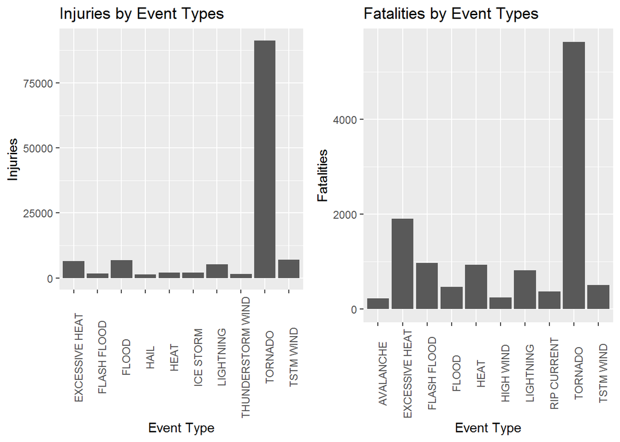

```r
p1 = ggplot(storm_most_injuries, aes(EVTYPE, total)) +
    geom_bar(stat = "identity") +
    theme(axis.text.x = element_text(angle=90)) +
    ggtitle("Injuries by Event Types") +
    xlab("Event Type") + ylab("Injuries")

p2 = ggplot(storm_most_fatalities, aes(EVTYPE, total)) +
    geom_bar(stat = "identity") +
    theme(axis.text.x = element_text(angle=90)) +
    ggtitle("Fatalities by Event Types") +
    xlab("Event Type") + ylab("Fatalities")

ggarrange(p1, p2)
```

##### 3.4 Biggest weather related events having economic consequences (Property Damages):

```r
propertyDamages
```

```
## # A tibble: 10 x 2
##    EVTYPE                   total
##    <fct>                    <dbl>
##  1 FLOOD             144657709800
##  2 HURRICANE/TYPHOON  69305840000
##  3 TORNADO            56925660480
##  4 STORM SURGE        43323536000
##  5 FLASH FLOOD        16140811510
##  6 HAIL               15727367220
##  7 HURRICANE          11868319010
##  8 TROPICAL STORM      7703890550
##  9 WINTER STORM        6688497250
## 10 HIGH WIND           5270046260
```

##### 3.5 Biggest weather related events having economic consequences (Crop Damages):

```r
cropDamages
```

```
## # A tibble: 10 x 2
##    EVTYPE                  total
##    <fct>                   <dbl>
##  1 DROUGHT           13972566000
##  2 FLOOD              5661968450
##  3 RIVER FLOOD        5029459000
##  4 ICE STORM          5022113500
##  5 HAIL               3025537450
##  6 HURRICANE          2741910000
##  7 HURRICANE/TYPHOON  2607872800
##  8 FLASH FLOOD        1421317100
##  9 EXTREME COLD       1292973000
## 10 FROST/FREEZE       1094086000
```

##### 3.6 Drawing charts:

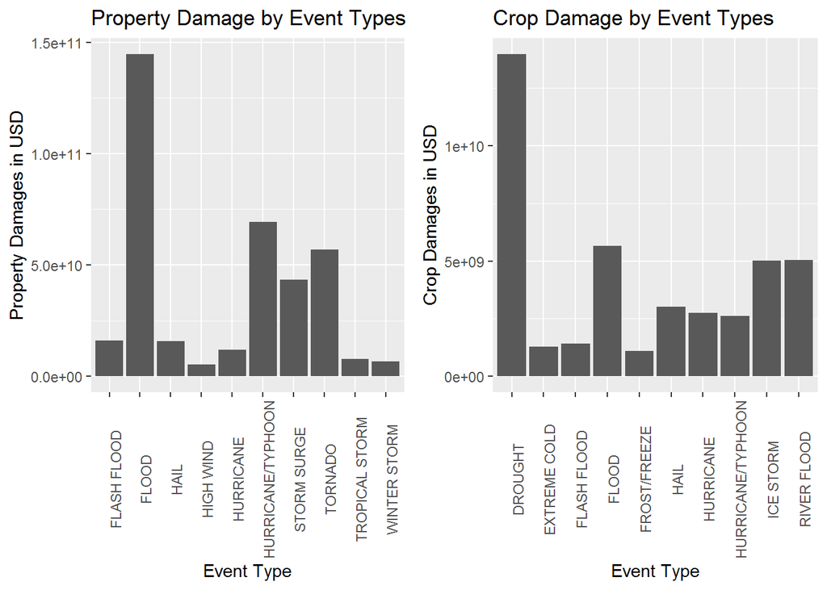

```r
p1 = ggplot(propertyDamages, aes(EVTYPE, total)) +
    geom_bar(stat = "identity") +
    theme(axis.text.x = element_text(angle=90)) +
    ggtitle("Property Damage by Event Types") +
    xlab("Event Type") + ylab("Property Damages in USD")

p2 = ggplot(cropDamages, aes(EVTYPE, total)) +
    geom_bar(stat = "identity") +
    theme(axis.text.x = element_text(angle=90)) +
    ggtitle("Crop Damage by Event Types") +
    xlab("Event Type") + ylab("Crop Damages in USD")

ggarrange(p1, p2)
```